# Improved Classification with Super Learner

Emily Robinson

December 12, 2018

#### Ensemble Modeling Overview

Imagine there is a jar of marbles and each person is asked to guess how many marbles are in the jar. Some individuals will guess over and some will guess under. What happens if you average the guesses? As technology has advanced, so have statistical models. There are now multiple choices of models for classification including: logistic regression, support vector machines, discriminant analysis, classification trees, etc. The issue arises when deciding which one to use and which tuning parameters to select for each given model. A solution that may improve the classification rates is to combine all predictions into one, more improved prediction (Steinki and Mohammad 2015). This is the basis idea behind ensemble modeling. In class, we discussed a variety of ensemble model methods including: model averaging, bagging, random forests, boosting, bumping, and stacking. The focus of this report is on stacking. I will introduce an R package, `SuperLearner`, and fit a few base models using classification methods we learned in class and evaluate the area under the curve (AUC) of the receiver operating characteristic (ROC). A ROC curve is a plot of the true positive rate (sensitivity) against the false positive rate (1-specificity) for the different possible cutpoints of a diagnostic test. This shows the tradeoff between sensitivity and specificity. To compare models, we calculate the AUC, a higher AUC indicates a better fit. After fitting the base models, I will combine the base learners into a super learner and compare the final model to the base learners.

####Stacking Stacking is a procedure where multiple learner modules are applied on a dataset to extract multiple predictions, which are then combined into one composite prediction. There are three main steps in stacking: ensemble generation (homogeneous if all base models belong to the same class of models or heterogeneous if all base models belong to a diverse set of models), ensemble pruning, and ensemble integration. Diversity is considered one of the key success factors of ensembles.

Suppose that $M$ predictors are available, $\hat{f_1}, \hat{f_2}, ..., \hat{f_M}$. Under a loss or risk function, a weight vector $\textbf{w}$ is created and the predictor
$$\hat{f}(x)=\sum_{m=1}^{M}w_m\hat{f_m}(x).$$
These weights are then optimized over a given function such as minimizing the mean square error or maximizing area under the curve (AUC) of receiver operating characteristic (ROC) using cross validation techniques.

Vardeman (2018) explains the theory behind stacking. Consider $M=2$, with the loss function defined as the mean squared error. Then $E[y-\hat{f}_1(x)]=0$ and $E[y-\hat{f}_2(x)]=0$. Define $\hat{f}_\alpha = \alpha\hat{f}_1+(1-\alpha)\hat{f}_2.$ Then,

$$\begin{align}
E[(y-\hat{f}_\alpha(x))^2] &= E[(\alpha\hat{f}_1+(1-\alpha)\hat{f}_2)^2]\\
&= Var(\alpha\hat{f}_1+(1-\alpha)\hat{f}_2)\\
&= (\alpha, 1-\alpha) \text{COV} \begin{pmatrix} y - \hat{f}_1(x) \\ y -\hat{f}_2(x) \end{pmatrix} \begin{pmatrix} \alpha \\ 1-\alpha \end{pmatrix}
\end{align}$$

Since this is a quadratic function of $\alpha,$ that has a minimum, there is a minimizing $\alpha$ that produces a better expected loss function than either $\hat{f}_1(x)$ or $\hat{f}_2(x)$.

In general,
$$\textbf{w}^{stack}=\underset{w}\arg\min\sum_{i=1}^N\left(y_i - \sum_{m=1}^M w_m\hat{f}_m^i(x_i)\right)^2$$
for the $m^th$ predictor fit to the training set with the $i^th$ case removed. This optimizes a kind of leave-one-out cross validation error for a linear combination of $\hat{f}_m's$. An ad hoc version of stacking-type averaging is more common and is based on an informal consideration of one’s (CV-supported) evaluation of the effectiveness of individual predictors correlations. Recall that a diverse set of base predictors is considered one of the key success factors of ensembles.

####Diabetes Dataset The dataset I have selected for my project is the Pima Indians Diabetes Database found on Kaggle through the UCI data repository, originally from the National Institute of Diabetes and Digestive and idney Diseases. The patients in this study are all females at least age 21 years old and of Pima Indian heritage. The target variable, Outcome, is binary and indicates whether or not a patient has diabetes. The objective is to correctly classify individuals to have diabetes or not based on several medical predictor variables such as the number of pregnancies the patient has had, their BMI, glucose level, insulin level, blood pressure, age, and diabeties pedigree function (DPF) (Smith et al. 1988).

#### Diagnostics

Testing for outliers, cooks distance, and influential points, the plots below indicate six points which were further removed from the dataset for modeling purposes.

```
## No Studentized residuals with Bonferroni p < 0.05
## Largest |rstudent|:
##     rstudent unadjusted p-value Bonferroni p
## 350 2.967294          0.0030043           NA
```

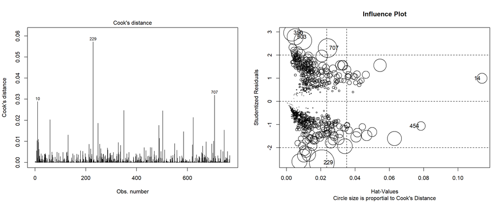

```
##       StudRes         Hat       CookD
## 14   1.002281 0.114022424 0.009536169
## 229 -2.634163 0.020610966 0.057205591
## 350  2.967294 0.003069042 0.024729204
## 454 -1.057796 0.078351507 0.007159288
## 503  2.786460 0.005137660 0.024505179
## 707  2.306667 0.023944183 0.031920741
```

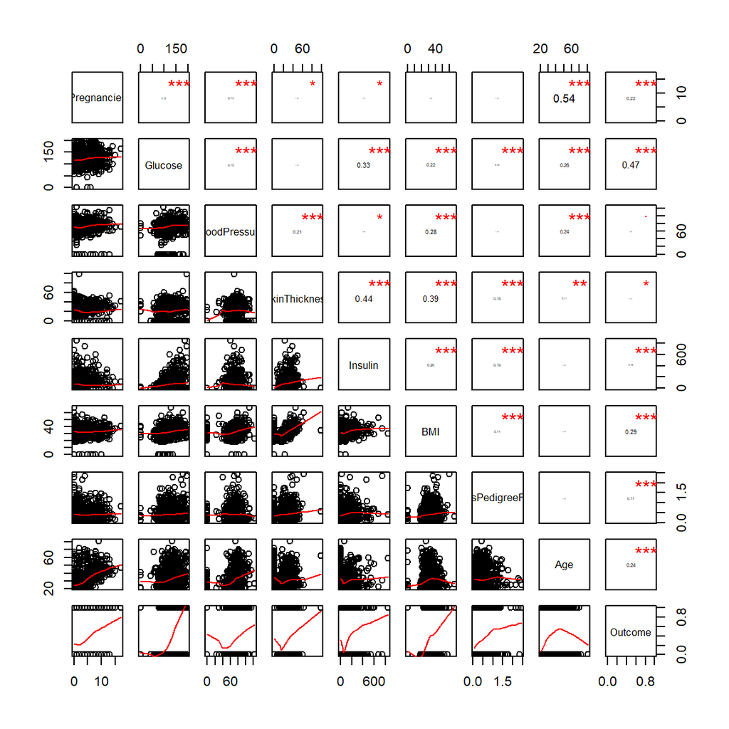

```r
Diabetes <- Diabetes[-c(14, 229, 350, 454, 503, 707),]
outcome  <- Diabetes$Outcome
data     <- subset(Diabetes, select = -Outcome)

# Create train & test sets
set.seed(904)
pct = 0.6
train_obs = sample(nrow(data), floor(nrow(data)*pct))
X_train = data[train_obs, ]
X_holdout = data[-train_obs, ]
Y_train = outcome[train_obs]
Y_holdout = outcome[-train_obs]

table(Y_train, useNA = "ifany")
```

```
## Y_train
##   0   1
## 297 160
```

Exploring the dataset, we obtain the following coefficients from the logistic regression model using `glm()`. We observe that the chances of having diabietes increases as the number of pregnancies, glucose levels, BMI, diabetes pedigree function, and age increase while the chances of having diabetes decrease as blood pressure, skin thickness, and insulin levels increase.

```
##              (Intercept)              Pregnancies                  Glucose
##             -9.033836090              0.120943571              0.038777313
##            BloodPressure            SkinThickness                  Insulin
##             -0.013052960             -0.001082154             -0.001094749
##                      BMI DiabetesPedigreeFunction                      Age
##              0.092884435              1.146457478              0.014083702
```

Looking at the variable importance and added variable plots, glucose is the most important predictor for the outcome of diabetes, followed by BMI, and age, diabetes pedigree function, blood pressure, pregnancies, insulin, and skin thickness.

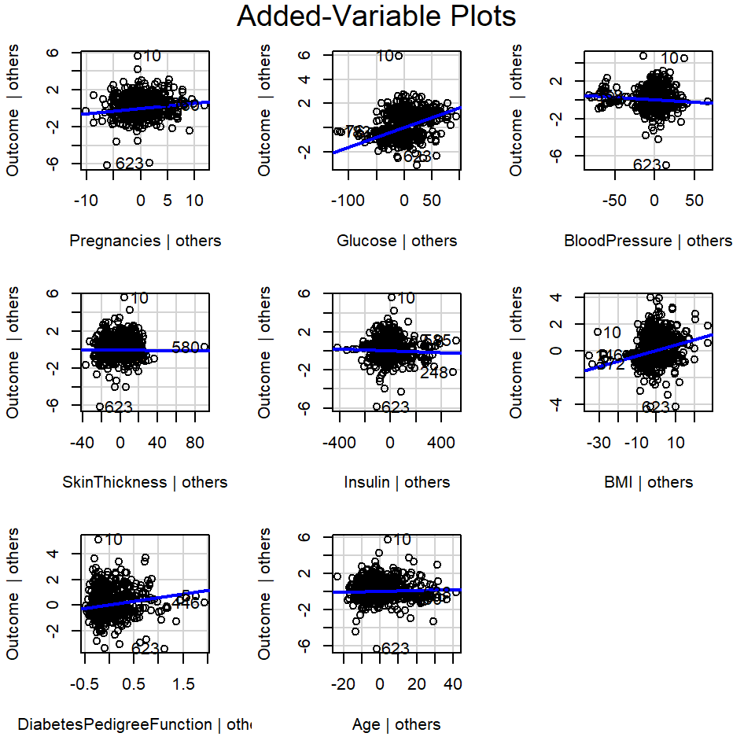

#### Super Learner

SuperLearner was developed by Polley et al. (2018), a prediction algorithm that applies any set of candidate learners and uses cross-validation to select between them. The set of candiate learners can be viewed using `listWrappers()`. Each wrapper calls the library in which the original learner was developed. For example, if you want to run `SL.randomForest`, then `library(randomForest)` must be installed. The screening algorithms serve the purpose of dimension reduction. Naimi and Balzer (2018)

```r
library(SuperLearner)
listWrappers()
```

```
## All prediction algorithm wrappers in SuperLearner:
```

```
##  [1] "SL.bartMachine"      "SL.bayesglm"         "SL.biglasso"
##  [4] "SL.caret"            "SL.caret.rpart"      "SL.cforest"
##  [7] "SL.earth"            "SL.extraTrees"       "SL.gam"
## [10] "SL.gbm"              "SL.glm"              "SL.glm.interaction"
## [13] "SL.glmnet"           "SL.ipredbagg"        "SL.kernelKnn"
## [16] "SL.knn"              "SL.ksvm"             "SL.lda"
## [19] "SL.leekasso"         "SL.lm"               "SL.loess"
## [22] "SL.logreg"           "SL.mean"             "SL.nnet"
## [25] "SL.nnls"             "SL.polymars"         "SL.qda"
## [28] "SL.randomForest"     "SL.ranger"           "SL.ridge"
## [31] "SL.rpart"            "SL.rpartPrune"       "SL.speedglm"
## [34] "SL.speedlm"          "SL.step"             "SL.step.forward"
## [37] "SL.step.interaction" "SL.stepAIC"          "SL.svm"
## [40] "SL.template"         "SL.xgboost"
```

```
##
## All screening algorithm wrappers in SuperLearner:
```

```
## [1] "All"
## [1] "screen.corP"           "screen.corRank"        "screen.glmnet"
## [4] "screen.randomForest"   "screen.SIS"            "screen.template"
## [7] "screen.ttest"          "write.screen.template"
```

#### Fit Base Learners

```r
sl_glm = SuperLearner(Y = Y_train, X = X_train, family = binomial(), SL.library = "SL.glm")
sl_glm
```

```
##
## Call:
## SuperLearner(Y = Y_train, X = X_train, family = binomial(), SL.library = "SL.glm")
##
##
##
##                 Risk Coef
## SL.glm_All 0.1501103    1
```

```r
pred_glm = predict(sl_glm, X_holdout)
AUC_eval("glm", pred_glm$pred, Y_holdout)
```

```
## [1] 0.8156812
```

Taking a look at the code for the `SL.glmnet()` wrapper, we can see that alpha is set to one, indicating that it defaults to lasso regression.

```r
SL.glmnet
```

```
## function (Y, X, newX, family, obsWeights, id, alpha = 1, nfolds = 10,
##     nlambda = 100, useMin = TRUE, loss = "deviance", ...)
## {
##     .SL.require("glmnet")
##     if (!is.matrix(X)) {
##         X <- model.matrix(~-1 + ., X)
##         newX <- model.matrix(~-1 + ., newX)
##     }
##     fitCV <- glmnet::cv.glmnet(x = X, y = Y, weights = obsWeights,
##         lambda = NULL, type.measure = loss, nfolds = nfolds,
##         family = family$family, alpha = alpha, nlambda = nlambda,
##         ...)
##     pred <- predict(fitCV, newx = newX, type = "response", s = ifelse(useMin,
##         "lambda.min", "lambda.1se"))
##     fit <- list(object = fitCV, useMin = useMin)
##     class(fit) <- "SL.glmnet"
##     out <- list(pred = pred, fit = fit)
##     return(out)
## }
## <bytecode: 0x000000001d628808>
## <environment: namespace:SuperLearner>
```

```r
sl_lasso = SuperLearner(Y = Y_train, X = X_train, family = binomial(), SL.library = "SL.glmnet")
sl_lasso
```

```
##
## Call:
## SuperLearner(Y = Y_train, X = X_train, family = binomial(), SL.library = "SL.glmnet")
##
##
##
##                    Risk Coef
## SL.glmnet_All 0.1511311    1
```

```r
pred_lasso = predict(sl_lasso, X_holdout)
AUC_eval("lasso", pred_lasso$pred, Y_holdout)
```

[output not shown]

```r
set.seed(904)
learners    = create.Learner("SL.glmnet", params = list(alpha = 0))
learners$names
```

```
## [1] "SL.glmnet_1"
```

```r
sl_ridge = SuperLearner(Y = Y_train, X = X_train, family = binomial(), SL.library = learners$names)
sl_ridge
```

```
##
## Call:
## SuperLearner(Y = Y_train, X = X_train, family = binomial(), SL.library = learners$names)
##
##
##
##                      Risk Coef
## SL.glmnet_1_All 0.1510155    1
```

```r
pred_ridge = predict(sl_ridge, X_holdout)
AUC_eval("ridge", pred_ridge$pred, Y_holdout)
```

```
## [1] 0.8209912
```

####Stacked Model To combine base models, we define a library of base learners. Super learner then uses cross validation to minimize the selected method, `method.NNLS()`, to minimize the mean square error. Other optimization methods include: `method.NNLS2()`, `method.NNloglik()`, `method.CC_LS()`, and `method.AUC(nlopt_method=NULL, optim_method="L-BFGS-B", bounds=c(0, Inf), normalize=TRUE)`. Running the initial stacked model below, we obtain the following risks and model weights.

```r
SL.library <- c("SL.glm", "SL.gam", "SL.glmnet", "SL.glmnet_1", "SL.ranger", "SL.ksvm", "SL.mean")
set.seed(904)
sl_stacked = SuperLearner(Y = Y_train, X = X_train, family = binomial(), SL.library = SL.library,
                          verbose = F, cvControl = list(V = 5), method = "method.NNLS")
sl_stacked
```

```
##
## Call:
## SuperLearner(Y = Y_train, X = X_train, family = binomial(), SL.library = SL.library,
##     method = "method.NNLS", verbose = F, cvControl = list(V = 5))
##
##
##                      Risk        Coef
## SL.glm_All      0.1518958 0.055268351
## SL.gam_All      0.1518958 0.000000000
## SL.glmnet_All   0.1511216 0.000000000
## SL.glmnet_1_All 0.1504423 0.884281802
## SL.ranger_All   0.1624184 0.007314434
## SL.ksvm_All     0.1627421 0.053135414
## SL.mean_All     0.2287339 0.000000000
```

In order to compare models, the function `CV.SuperLearner()` implements five random assignments of observations to the five fold cross validations to obtain five different weighted models.

```r
set.seed(904)
cv_stacked <- CV.SuperLearner(Y = Y_train, X = X_train, family = binomial(), SL.library = SL.library,
                              verbose = F, cvControl = list(V = 5), method = "method.NNLS")
```

[output not shown]

[output cut: 109 more lines]

[output not shown]

```r
summary(cv_stacked)
```

```
##
## Call:
## CV.SuperLearner(Y = Y_train, X = X_train, family = binomial(), SL.library = SL.library,
##     method = "method.NNLS", verbose = F, cvControl = list(V = 5))
##
## Risk is based on: Mean Squared Error
##
## All risk estimates are based on V =  5
##
##        Algorithm     Ave        se     Min     Max
##    Super Learner 0.15364 0.0095270 0.12748 0.20017
##      Discrete SL 0.15096 0.0094375 0.12748 0.19571
##       SL.glm_All 0.15183 0.0104358 0.12493 0.19716
##       SL.gam_All 0.15183 0.0104358 0.12493 0.19716
##    SL.glmnet_All 0.15086 0.0100379 0.12388 0.19571
##  SL.glmnet_1_All 0.15037 0.0092181 0.12748 0.19274
##    SL.ranger_All 0.16443 0.0091860 0.12936 0.22053
##      SL.ksvm_All 0.16232 0.0095447 0.13524 0.19826
##      SL.mean_All 0.22866 0.0067506 0.21055 0.24468
```

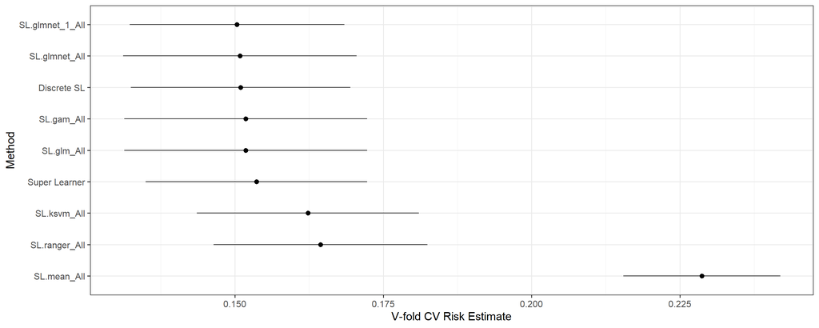

```r
plot(cv_stacked) + theme_bw(base_size = 15)
```

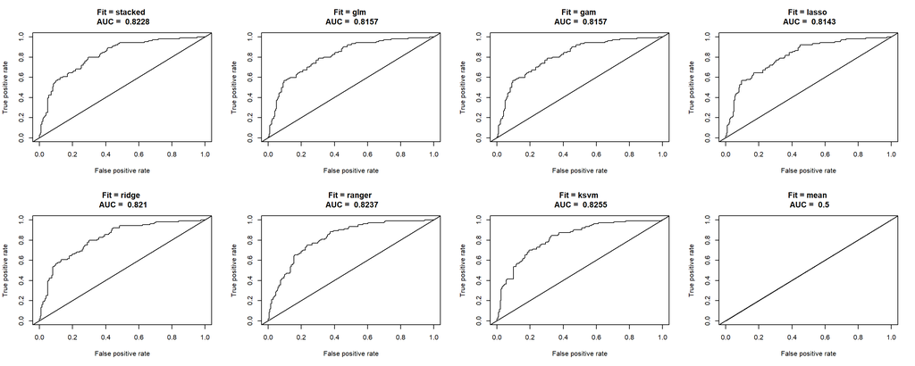

####Modify Learners In attempts to improve the AUC of the super learner model, I selected the best parameters for the base ranger model, recall that ranger is a version of random forest. This can be seen from the code below.

```r
SL.ranger
```

```
## function (Y, X, newX, family, obsWeights, num.trees = 500, mtry = floor(sqrt(ncol(X))),
##     write.forest = TRUE, probability = family$family == "binomial",
##     min.node.size = ifelse(family$family == "gaussian", 5, 1),
##     replace = TRUE, sample.fraction = ifelse(replace, 1, 0.632),
##     num.threads = 1, verbose = T, ...)
## {
##     .SL.require("ranger")
##     if (family$family == "binomial") {
##         Y = as.factor(Y)
##     }
##     if (is.matrix(X)) {
##         X = data.frame(X)
##     }
##     fit <- ranger::ranger(`_Y` ~ ., data = cbind(`_Y` = Y, X),
##         num.trees = num.trees, mtry = mtry, min.node.size = min.node.size,
##         replace = replace, sample.fraction = sample.fraction,
##         case.weights = obsWeights, write.forest = write.forest,
##         probability = probability, num.threads = num.threads,
##         verbose = verbose)
##     pred <- predict(fit, data = newX)$predictions
##     if (family$family == "binomial") {
##         pred = pred[, "1"]
##     }
##     fit <- list(object = fit, verbose = verbose)
##     class(fit) <- c("SL.ranger")
##     out <- list(pred = pred, fit = fit)
##     return(out)
## }
## <bytecode: 0x000000001d52e650>
## <environment: namespace:SuperLearner>
```

Adjusting the number of variables selected at each split and the number of trees fitted, I compare sixteen different ranger models.

```r
mtry_seq    <- seq(2, 5, 1)
n.trees_seq <- seq(500, 800, 100)
learners.ranger <- create.Learner("SL.ranger", tune = list(mtry = mtry_seq, num.trees = n.trees_seq))
learners.ranger$names
```

```
##  [1] "SL.ranger_1"  "SL.ranger_2"  "SL.ranger_3"  "SL.ranger_4"
##  [5] "SL.ranger_5"  "SL.ranger_6"  "SL.ranger_7"  "SL.ranger_8"
##  [9] "SL.ranger_9"  "SL.ranger_10" "SL.ranger_11" "SL.ranger_12"
## [13] "SL.ranger_13" "SL.ranger_14" "SL.ranger_15" "SL.ranger_16"
```

In order to compare the various combinations of models, I placed the learners defined above into my super learner library.

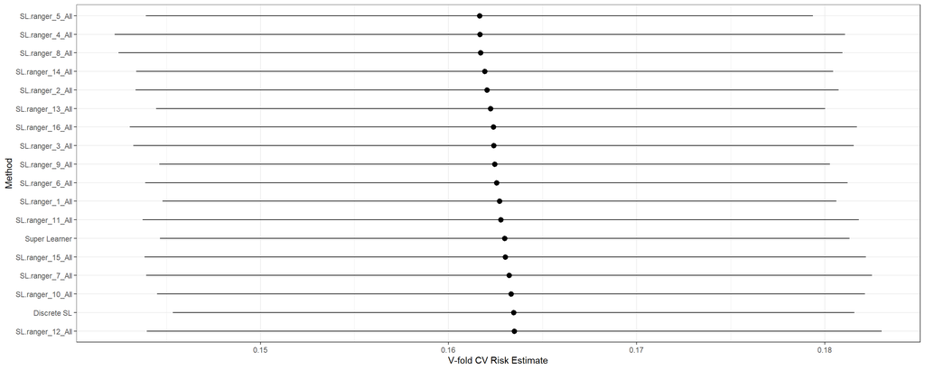

```r
set.seed(904)
cv_stacked.ranger <- CV.SuperLearner(Y = Y_train, X = X_train, family = binomial(), SL.library = learners.ranger$names, verbose = F, cvControl = list(V = 5), method = "method.NNLS")
plot(cv_stacked.ranger) + theme_bw()
```

The best ranger model was `SL.ranger_5` with `mtry = 2` and `num.trees = 600`.

```r
SL.ranger_5
```

```
## function (...)
## SL.ranger(..., mtry = 2, num.trees = 600)
## <bytecode: 0x000000002600d1c8>
```

For a revised super learner model, I kept the logistic generalized linear model, adjusted the gernalized additive model as below, kept the ridge regression model, adjusted the ranger model as below, and kept the mean model.

```
## function (...)
## SL.gam(..., deg.gam = 4, cts.num = 3)
## <bytecode: 0x0000000028f0f1b8>
```

```
## function (...)
## SL.glmnet(..., alpha = 0)
## <bytecode: 0x000000001db0b200>
```

```
## function (...)
## SL.ranger(..., mtry = 2, num.trees = 600)
## <bytecode: 0x000000002600d1c8>
```

```r
SL.library2 <- c("SL.glm", "SL.gam_12", "SL.glmnet_1",  "SL.ranger_5", "SL.mean")
set.seed(904)
cv_stacked2 <- CV.SuperLearner(Y = Y_train, X = X_train, family = binomial(), SL.library = SL.library2,
                               verbose = F, cvControl = list(V = 5), method = "method.NNLS")
```

[output not shown]

[output cut: 109 more lines]

[output not shown]

```r
review_weights(cv_stacked2)
```

```
##                 mean(weight)        sd       min       max
## SL.glmnet_1_All    0.5478432 0.4228494 0.1127412 1.0000000
## SL.gam_12_All      0.1941200 0.2588027 0.0000000 0.5103122
## SL.ranger_5_All    0.1614616 0.1808809 0.0000000 0.4043823
## SL.glm_All         0.0965753 0.2159489 0.0000000 0.4828765
## SL.mean_All        0.0000000 0.0000000 0.0000000 0.0000000
```

```
##
## Call:
## CV.SuperLearner(Y = Y_train, X = X_train, family = binomial(), SL.library = SL.library2,
##     method = "method.NNLS", verbose = F, cvControl = list(V = 5))
##
## Risk is based on: Mean Squared Error
##
## All risk estimates are based on V =  5
##
##        Algorithm     Ave        se     Min     Max
##    Super Learner 0.15298 0.0094776 0.12740 0.19925
##      Discrete SL 0.15037 0.0092181 0.12748 0.19274
##       SL.glm_All 0.15183 0.0104358 0.12493 0.19716
##    SL.gam_12_All 0.15183 0.0104358 0.12493 0.19716
##  SL.glmnet_1_All 0.15037 0.0092181 0.12748 0.19274
##  SL.ranger_5_All 0.16308 0.0091416 0.13025 0.22119
##      SL.mean_All 0.22866 0.0067506 0.21055 0.24468
```

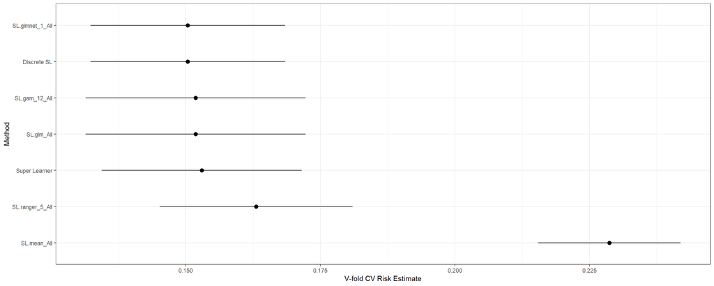

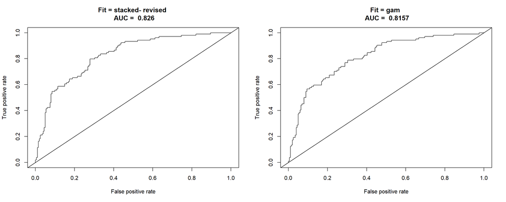

A major limitation to super learner is the time constraint and computing power. Another limitation is that there is no capability to look into the components of the models through the super learner package. For example, I was unable to look at the coefficients for `SL.glm()`. Lastly, the optimization method for AUC did not work correctly as I kept obtaining errors, after searching online, it appeared that other users have run into the same issue. Overall, due to a statisticians toolbox having so many potential models in it, I found super learner to be a simple way to compare all the models.

#### References

Naimi, Ashley I., and Laura B. Balzer. 2018. “Stacked Generalization: An Introduction to Super Learning.” *European Journal of Epidemiology* 33 (5): 459–64. https://doi.org/10.1007/s10654-018-0390-z.

Polley, Eric, Erin LeDell, Chris Kennedy, and Mark van der Laan. 2018. *SuperLearner: Super Learner Prediction*. https://CRAN.R-project.org/package=SuperLearner.

Smith, Jack W., J. E. Everhart, W. C. Dickson, W. C. Knowler, and R. S. Johannes. 1988. “Using the Adap Learning Algorithm to Forecast the Onset of Diabetes Mellitus.” In *Proceedings of the Annual Symposium on Computer Application in Medical Care*, edited by NA, 261–65. American Medical Informatics Association.

Steinki, Oliver, and Ziad Mohammad. 2015. “Introduction to Ensemble Learning.” *European Journal of Epidemiology*. https://doi.org/10.2139/ssrn.2634092.

Vardeman, S. B. 2018. “Lecture Notes on Modern Multivariate Statistical Learning-Version Ii.” *European Journal of Epidemiology*, 109–12. http://www.analyticsiowa.com/wp-content/uploads/2018/07/StatLearningNotesII.pdf.